# Course Project Description

2024-03-02

Abstract

# Introduction

# Exploratory analysis

```r
# install.packages("ROCR")
suppressWarnings(library(tidyverse))
suppressWarnings(library(dplyr))
suppressWarnings(library(caret))
suppressWarnings(library(ROCR))
suppressWarnings(library(knitr))
suppressWarnings(library(kableExtra))
suppressWarnings(library(MASS))
```

## Dataset

```r
path <- getwd()
setwd(path)
session=list()
for(i in 1:18){
  session[[i]]=readRDS(paste('./Data/session',i,'.rds',sep=''))
  # print(session[[i]]$mouse_name)
  # print(session[[i]]$date_exp)
}
names(session[[1]])
```

```
## [1] "contrast_left"  "contrast_right" "feedback_type"  "mouse_name"
## [5] "brain_area"     "date_exp"       "spks"           "time"
```

```r
summary(session[[3]])
```

```
##                Length Class  Mode
## contrast_left  228    -none- numeric
## contrast_right 228    -none- numeric
## feedback_type  228    -none- numeric
## mouse_name       1    -none- character
## brain_area     619    -none- character
## date_exp         1    -none- character
## spks           228    -none- list
## time           228    -none- list
```

Summarize the brain areas and overall success rates:

```r
# feedback_type
n_session <- length(session)

n_trial <- sum(sapply(session, function(x) length(x$feedback_type)))
n_success <- sum(sapply(session, function(x) sum(x$feedback_type == 1)))

n_success / n_trial
```

```
## [1] 0.7100964
```

Over 70% trials are success.

```r
# brain area
area <- unique(unlist(lapply(session, function(x) unique(x$brain_area))))

n_area <- length(area)
n_area
```

```
## [1] 62
```

There are 62 levels in brain area.

Next, by summarizing across sessions, we can gain insights into the characteristics of the dataset. For example, it includes the number of mice involved in the experiments, the time span of the experiments, the diversity of brain areas, the quantity of neurons, and the success rates. It helps us to have more knowledge of the data structure.

```r
# Summarize the information across sessions:

# Knowing what summary we want to report, we can create a tibble:
# All values in this function serve only as place holders

n.session=length(session)

# in library tidyverse
meta <- tibble(
  mouse_name = rep('name',n.session),
  date_exp =rep('dt',n.session),
  n_brain_area = rep(0,n.session),
  n_neurons = rep(0,n.session),
  n_trials = rep(0,n.session),
  success_rate = rep(0,n.session)
)


for(i in 1:n.session){
  tmp = session[[i]];
  meta[i,1]=tmp$mouse_name;
  meta[i,2]=tmp$date_exp;
  meta[i,3]=length(unique(tmp$brain_area));
  meta[i,4]=dim(tmp$spks[[1]])[1];
  meta[i,5]=length(tmp$feedback_type);
  meta[i,6]=mean(tmp$feedback_type+1)/2;
}

kable(meta, format = "html", table.attr = "class='table table-striped'", digits = 2, caption = "Summary of the Information Across Sessions")
```

Summary of the Information Across Sessions

| mouse_name | date_exp | n_brain_area | n_neurons | n_trials | success_rate |
| --- | --- | --- | --- | --- | --- |
| Cori | 2016-12-14 | 8 | 734 | 114 | 0.61 |
| Cori | 2016-12-17 | 5 | 1070 | 251 | 0.63 |
| Cori | 2016-12-18 | 11 | 619 | 228 | 0.66 |
| Forssmann | 2017-11-01 | 11 | 1769 | 249 | 0.67 |
| Forssmann | 2017-11-02 | 10 | 1077 | 254 | 0.66 |
| Forssmann | 2017-11-04 | 5 | 1169 | 290 | 0.74 |
| Forssmann | 2017-11-05 | 8 | 584 | 252 | 0.67 |
| Hench | 2017-06-15 | 15 | 1157 | 250 | 0.64 |
| Hench | 2017-06-16 | 12 | 788 | 372 | 0.69 |
| Hench | 2017-06-17 | 13 | 1172 | 447 | 0.62 |
| Hench | 2017-06-18 | 6 | 857 | 342 | 0.80 |
| Lederberg | 2017-12-05 | 12 | 698 | 340 | 0.74 |
| Lederberg | 2017-12-06 | 15 | 983 | 300 | 0.80 |
| Lederberg | 2017-12-07 | 10 | 756 | 268 | 0.69 |
| Lederberg | 2017-12-08 | 8 | 743 | 404 | 0.76 |
| Lederberg | 2017-12-09 | 6 | 474 | 280 | 0.72 |
| Lederberg | 2017-12-10 | 6 | 565 | 224 | 0.83 |
| Lederberg | 2017-12-11 | 10 | 1090 | 216 | 0.81 |

## Session

Let’s take a look at Session 6.

The 1169 neurons in Session 6 are located in AUD, root, SSp, CA1, TH of the mouse brain. We can visualize the activities of these areas across the 290 trials.

Here I take the average number of spikes across neurons in each area as the activities and start my analysis on one trial.

I defineed a function named `average_spike_area` that calculates the average spike count for each brain area in a given trial of a session. Then, it tests the function with Session 6 and Trial 1.

```r
average_spike_area<-function(i.t,this_session){
  spk.trial = this_session$spks[[i.t]]
  area= this_session$brain_area
  spk.count=apply(spk.trial,1,sum)
  spk.average.tapply=tapply(spk.count, area, mean)
  return(spk.average.tapply)
  }


i.s=6 # indicator for this session

i.t=1 # indicator for this trial
# Test the function
average_spike_area(1,this_session = session[[i.s]])
```

```
##       AUD       CA1      root       SSp        TH
## 0.3170732 1.1111111 0.7484076 0.2727273 0.4153226
```

The output provides the average spike count for each brain area (AUD, CA1, root, SSp, TH). We can see that the CA1 area has a notably higher average spike count compared to other areas like AUD and SSp.

The purpose of this code is to create a dataframe containing the average spike counts for each brain area, feedback type, two contrasts, and trial ID.

```r
n.trial=length(session[[i.s]]$feedback_type)
n.area=length(unique(session[[i.s]]$brain_area ))
# Alternatively, you can extract these information in the meta that we created before.

# We will create a data frame that contain the average spike counts for each area, feedback type,  the two contrasts, and the trial id

trial.summary =matrix(nrow=n.trial,ncol= n.area+1+2+1)
for(i.t in 1:n.trial){
  trial.summary[i.t,]=c(average_spike_area(i.t,this_session = session[[i.s]]),
                          session[[i.s]]$feedback_type[i.t],
                        session[[i.s]]$contrast_left[i.t],
                        session[[i.s]]$contrast_right[i.s],
                        i.t)
}

colnames(trial.summary)=c(names(average_spike_area(i.t,this_session = session[[i.s]])), 'feedback', 'left contr.','right contr.','id' )

# Turning it into a data frame
trial.summary <- as_tibble(trial.summary)
```

From the average spike counts in each brain area, we can understand which brain regions are most active when stimulated.

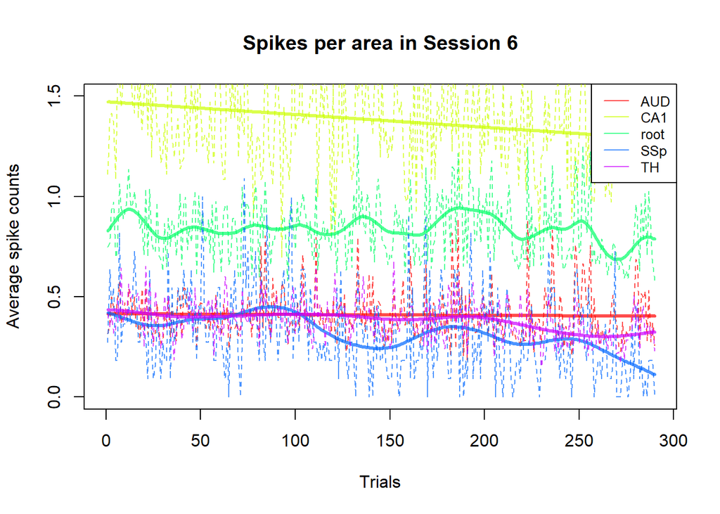

```r
area.col=rainbow(n=n.area,alpha=0.7)
# In base R, I usually initiate a blank plot before drawing anything on it
plot(x=1,y=0, col='white',xlim=c(0,n.trial),ylim=c(0,1.5), xlab="Trials",ylab="Average spike counts", main=paste("Spikes per area in Session", i.s))


for(i in 1:n.area){
  lines(y=trial.summary[[i]],x=trial.summary$id,col=area.col[i],lty=2,lwd=1)
  lines(smooth.spline(trial.summary$id, trial.summary[[i]]),col=area.col[i],lwd=3)
  }
legend("topright",
  legend = colnames(trial.summary)[1:n.area],
  col = area.col,
  lty = 1,
  cex = 0.8
)
```

CA1 has the highest average spike counts. However, there is a decreasing trend as the number of experiments increases. The root region has relatively higher average spike counts and shows fluctuating patterns. The average spike counts in the other three regions are similar. But AUD shows a flat trend and is not affected by the number of experiments.

## Trial

At the trial level, we can visualize the activities of all neurons in this session.

```r
plot.trial<-function(i.t,area, area.col,this_session){

    spks=this_session$spks[[i.t]];
    n.neuron=dim(spks)[1]
    time.points=this_session$time[[i.t]]

    plot(0,0,xlim=c(min(time.points),max(time.points)),ylim=c(0,n.neuron+1),col='white', xlab='Time (s)',yaxt='n', ylab='Neuron', main=paste('Trial ',i.t, 'feedback', this_session$feedback_type[i.t] ),cex.lab=1.5)
    for(i in 1:n.neuron){
        i.a=which(area== this_session$brain_area[i]);
        col.this=area.col[i.a]

        ids.spike=which(spks[i,]>0) # find out when there are spikes
        if( length(ids.spike)>0 ){
            points(x=time.points[ids.spike],y=rep(i, length(ids.spike) ),pch='.',cex=2, col=col.this)
        }


    }

legend("topright",
  legend = area,
  col = area.col,
  pch = 16,
  cex = 0.8
  )
  }
```

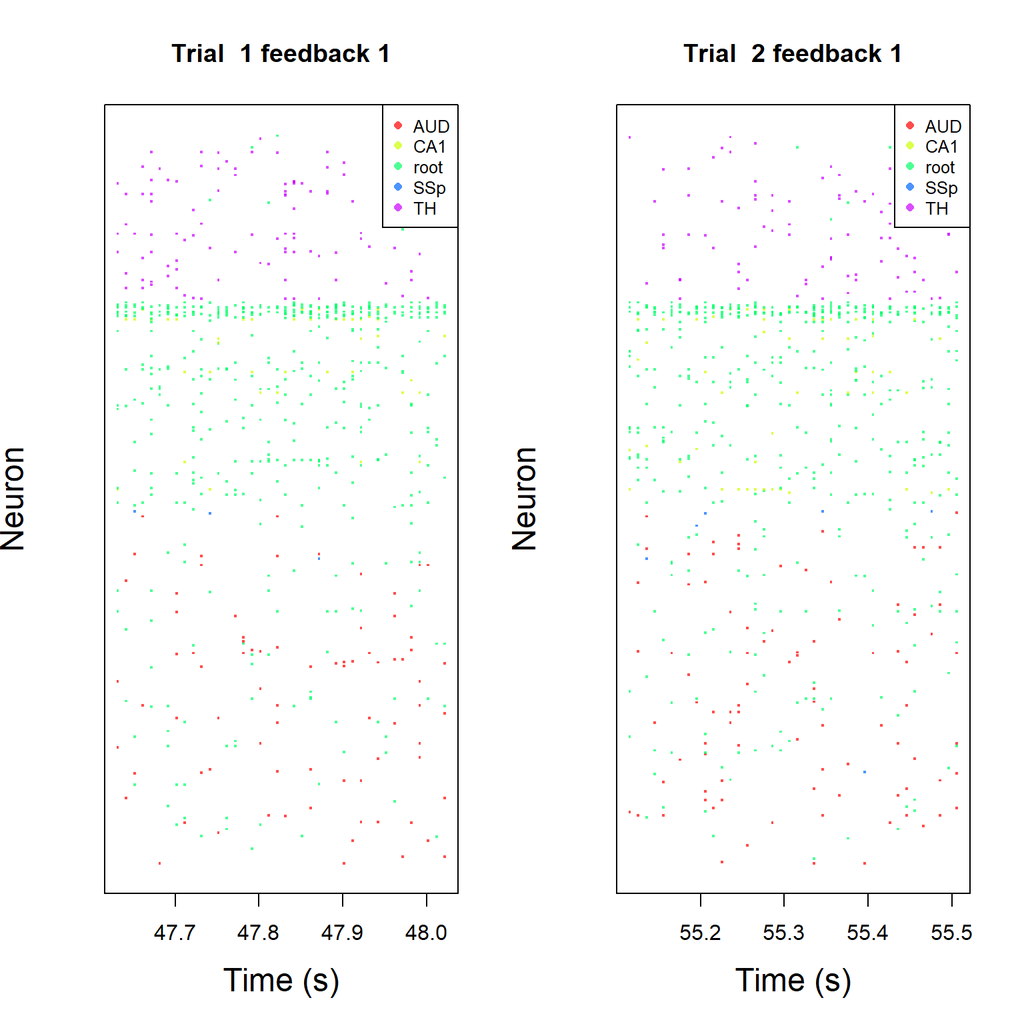

```r
varname=names(trial.summary);
area=varname[1:(length(varname)-4)]
par(mfrow=c(1,2))
plot.trial(1,area, area.col,session[[i.s]])
plot.trial(2,area, area.col,session[[i.s]])
```

```r
par(mfrow=c(1,1))
```

# Data integration

From the project description, we can see that the ultimate goal of the course project is to predict the outcome in the test set that contains 100 trials from Session 1 and Session 18. However, as we see from Milestone I, data structure differs across sessions. For instance, Session 1 contains 734 neurons from 8 brain areas, where Session 2 contains 1070 neurons from 5 brain areas.

Then I used the Benchmark method. It can ignore the information about specific neurons by averaging over their activities. In particular, for each trial, I first take the summation of spikes for each neuron, which results in a vector that contains the total number of spikes for all neurons during the 0.4 seconds in that trial; then, we take the average of the total number of spikes, which results in one number that is the average spike counts during that trial. Finally, I calculated the number of neurons that has spikes and computed the average number of spikes among active neurons.

```r
# create an empty dataframe
session_bench <- data.frame(matrix(ncol = 9, nrow = 0))

# loop through each session
for (i in 1:length(session)) {
  n_obs <- length(session[[i]]$feedback_type)
  mouse_name <- session[[i]]$mouse_name
  date_exp <- session[[i]]$date_exp
  n_brain_area <- length(unique(session[[i]]$brain_area))

  # loop through each trail
  for (j in 1:n_obs) {
    spks.trial <- session[[i]]$spks[[j]]

    # total spikes for each neuron
    total.spikes <- apply(spks.trial, 1, sum)

    # average spikes per neuron
    avg.spikes <- mean(total.spikes)

    # average spikes per active neuron
    active_neurons <- sum(total.spikes > 0)
    avg.active_neuron_spks <- sum(total.spikes) / active_neurons


    # create a vector containing the current trial's data
    current_trial <- c(i, mouse_name, date_exp, session[[i]]$contrast_left[j], session[[i]]$contrast_right[j], n_brain_area, avg.spikes, avg.active_neuron_spks, session[[i]]$feedback_type[[j]])

    session_bench <- rbind(session_bench, current_trial)
  }
}

# View the results
colnames(session_bench) <- c("session_ID", "mouse_name", "date_exp", "contrast_left", "contrast_right", "n_brain_area", "avg_spikes", "avg_active_neuron_spks", "feedback_type")
session_bench$feedback_type <- as.factor(session_bench$feedback_type)
head(session_bench)
```

```
##   session_ID mouse_name   date_exp contrast_left contrast_right n_brain_area
## 1          1       Cori 2016-12-14             0            0.5            8
## 2          1       Cori 2016-12-14             0              0            8
## 3          1       Cori 2016-12-14           0.5              1            8
## 4          1       Cori 2016-12-14             0              0            8
## 5          1       Cori 2016-12-14             0              0            8
## 6          1       Cori 2016-12-14             0              0            8
##         avg_spikes avg_active_neuron_spks feedback_type
## 1 1.58174386920981       3.80655737704918             1
## 2 1.31198910081744        3.4270462633452             1
## 3 1.84468664850136       3.94752186588921            -1
## 4 1.38147138964578       3.28155339805825            -1
## 5 1.42506811989101        3.4071661237785            -1
## 6 1.09400544959128       3.46120689655172             1
```

```r
# DataFrame
write.csv(session_bench, "session_bench.csv", row.names = FALSE)
rm(list = ls())
session_bench <- read_csv('session_bench.csv')
session_bench$feedback_type <- as.factor(session_bench$feedback_type)
```

In summary, I employ benchmark method 1, which involves summarizing brain_area, spks, and time into two numbers by averaging over spks and spks among active neurons.

# Predictive modeling

I fit a logistic regression on this data frame, using the feedback type as the outcome, and left contrast, right contrast, and average spks as the covariate.

```r
fit1 <- glm(feedback_type~contrast_left+contrast_right+avg_spikes, data = session_bench, family="binomial")
summary(fit1)
```

```
##
## Call:
## glm(formula = feedback_type ~ contrast_left + contrast_right +
##     avg_spikes, family = "binomial", data = session_bench)
##
## Deviance Residuals:
##     Min       1Q   Median       3Q      Max
## -1.9869  -1.4499   0.7721   0.8631   1.0535
##
## Coefficients:
##                Estimate Std. Error z value Pr(>|z|)
## (Intercept)     0.14781    0.09671   1.528   0.1264
## contrast_left   0.15515    0.08016   1.936   0.0529 .
## contrast_right -0.11918    0.08192  -1.455   0.1457
## avg_spikes      0.54714    0.06784   8.065 7.32e-16 ***
## ---
## Signif. codes:  0 '***' 0.001 '**' 0.01 '*' 0.05 '.' 0.1 ' ' 1
##
## (Dispersion parameter for binomial family taken to be 1)
##
##     Null deviance: 6118.2  on 5080  degrees of freedom
## Residual deviance: 6044.4  on 5077  degrees of freedom
## AIC: 6052.4
##
## Number of Fisher Scoring iterations: 4
```

Model 1 suggests that the avg_spikes variable has a significant association with the feedback_type. The other predictor variables, do not show a significant association with the response variable.

So the information of contrast_left and contrast_right are summarized into four factors in decision according to the scenrio because a same behavior in different scenrio results in different feedback_type.

```r
desicions <- c()
for (j in 1:length(session_bench$contrast_left)){
  if (session_bench$contrast_left[j] > session_bench$contrast_right[j]){
      decision = '1'
  } else if (session_bench$contrast_left[j] < session_bench$contrast_right[j]){
      decision = '2'
  } else if (session_bench$contrast_left[j] == session_bench$contrast_right[j]
             & session_bench$contrast_left[j] == 0){
      decision = '3'
  } else{
      decision = '4'
  }
  desicions <- cbind(desicions, decision)
}

session_bench$desicion <- as.factor(desicions)
session_bench
```

```
## # A tibble: 5,081 × 10
##    session_ID mouse_name date_exp   contrast_left contrast_right n_brain_area
##         <dbl> <chr>      <date>             <dbl>          <dbl>        <dbl>
##  1          1 Cori       2016-12-14           0             0.5             8
##  2          1 Cori       2016-12-14           0             0               8
##  3          1 Cori       2016-12-14           0.5           1               8
##  4          1 Cori       2016-12-14           0             0               8
##  5          1 Cori       2016-12-14           0             0               8
##  6          1 Cori       2016-12-14           0             0               8
##  7          1 Cori       2016-12-14           1             0.5             8
##  8          1 Cori       2016-12-14           0.5           0               8
##  9          1 Cori       2016-12-14           0             0               8
## 10          1 Cori       2016-12-14           0.5           0.25            8
## # ℹ 5,071 more rows
## # ℹ 4 more variables: avg_spikes <dbl>, avg_active_neuron_spks <dbl>,
## #   feedback_type <fct>, desicion <fct>
```

I fit a logistic regression model on the data frame. The outcome variable is feedback_type, and the covariates included mouse_name, decision, n_brain_area, avg_spikes, and avg_active_neuron_spks.

```r
fit2 <- glm(feedback_type~mouse_name + desicion + n_brain_area + avg_spikes + avg_active_neuron_spks, data = session_bench, family="binomial")
summary(fit2)
```

```
##
## Call:
## glm(formula = feedback_type ~ mouse_name + desicion + n_brain_area +
##     avg_spikes + avg_active_neuron_spks, family = "binomial",
##     data = session_bench)
##
## Deviance Residuals:
##     Min       1Q   Median       3Q      Max
## -2.3234  -1.2706   0.6642   0.8473   1.5241
##
## Coefficients:
##                        Estimate Std. Error z value Pr(>|z|)
## (Intercept)             0.00316    0.23507   0.013   0.9893
## mouse_nameForssmann     1.09854    0.13259   8.286  < 2e-16 ***
## mouse_nameHench         1.03020    0.13628   7.560 4.05e-14 ***
## mouse_nameLederberg     1.09560    0.11311   9.686  < 2e-16 ***
## desicion2              -0.16681    0.08196  -2.035   0.0418 *
## desicion3              -0.36890    0.08247  -4.473 7.71e-06 ***
## desicion4              -1.22248    0.12991  -9.410  < 2e-16 ***
## n_brain_area           -0.13671    0.01405  -9.728  < 2e-16 ***
## avg_spikes              1.19298    0.17413   6.851 7.34e-12 ***
## avg_active_neuron_spks -0.02130    0.11114  -0.192   0.8480
## ---
## Signif. codes:  0 '***' 0.001 '**' 0.01 '*' 0.05 '.' 0.1 ' ' 1
##
## (Dispersion parameter for binomial family taken to be 1)
##
##     Null deviance: 6118.2  on 5080  degrees of freedom
## Residual deviance: 5794.7  on 5071  degrees of freedom
## AIC: 5814.7
##
## Number of Fisher Scoring iterations: 4
```

And I performed stepwise variable selection (stepAIC) on the logistic regression model fit2 using both forward and backward selection directions.

```r
fit3 <- stepAIC(fit2, direction = "both")
```

```
## Start:  AIC=5814.7
## feedback_type ~ mouse_name + desicion + n_brain_area + avg_spikes +
##     avg_active_neuron_spks
##
##                          Df Deviance    AIC
## - avg_active_neuron_spks  1   5794.7 5812.7
## <none>                        5794.7 5814.7
## - avg_spikes              1   5841.9 5859.9
## - desicion                3   5888.7 5902.7
## - mouse_name              3   5889.7 5903.7
## - n_brain_area            1   5894.6 5912.6
##
## Step:  AIC=5812.74
## feedback_type ~ mouse_name + desicion + n_brain_area + avg_spikes
##
##                          Df Deviance    AIC
## <none>                        5794.7 5812.7
## + avg_active_neuron_spks  1   5794.7 5814.7
## - desicion                3   5889.1 5901.1
## - mouse_name              3   5890.4 5902.4
## - n_brain_area            1   5894.6 5910.6
## - avg_spikes              1   5956.7 5972.7
```

```r
summary(fit3)
```

```
##
## Call:
## glm(formula = feedback_type ~ mouse_name + desicion + n_brain_area +
##     avg_spikes, family = "binomial", data = session_bench)
##
## Deviance Residuals:
##     Min       1Q   Median       3Q      Max
## -2.3264  -1.2711   0.6643   0.8470   1.5274
##
## Coefficients:
##                     Estimate Std. Error z value Pr(>|z|)
## (Intercept)         -0.02897    0.16472  -0.176   0.8604
## mouse_nameForssmann  1.09806    0.13259   8.282  < 2e-16 ***
## mouse_nameHench      1.02302    0.13107   7.805 5.93e-15 ***
## mouse_nameLederberg  1.09246    0.11191   9.762  < 2e-16 ***
## desicion2           -0.16711    0.08194  -2.039   0.0414 *
## desicion3           -0.37088    0.08183  -4.533 5.83e-06 ***
## desicion4           -1.22274    0.12990  -9.413  < 2e-16 ***
## n_brain_area        -0.13673    0.01406  -9.726  < 2e-16 ***
## avg_spikes           1.16500    0.09477  12.292  < 2e-16 ***
## ---
## Signif. codes:  0 '***' 0.001 '**' 0.01 '*' 0.05 '.' 0.1 ' ' 1
##
## (Dispersion parameter for binomial family taken to be 1)
##
##     Null deviance: 6118.2  on 5080  degrees of freedom
## Residual deviance: 5794.7  on 5072  degrees of freedom
## AIC: 5812.7
##
## Number of Fisher Scoring iterations: 4
```

Clearly, Model2 and Model3 perform better than Model1. After variable selection, the following four variables, mouse_name, decision, n_brain_area, and avg_spikes, are found to be significant.

# Prediction performance on the test sets

The model’s performance was evaluated using session 1 and session 18 as the test sets.

```r
session_1 <- subset(session_bench, session_ID==1)

pred1 <- predict(fit1, session_1 %>% dplyr::select(-feedback_type), type = 'response')
pred2 <- predict(fit2, session_1 %>% dplyr::select(-feedback_type), type = 'response')
pred3 <- predict(fit3, session_1 %>% dplyr::select(-feedback_type), type = 'response')
```

```r
find_best_threshold <- function(pred, actual, thresholds) {
  best_threshold <- 0
  min_error_rate <- Inf

  for (threshold in thresholds) {
    prediction <- ifelse(pred > threshold, '1', '-1')
    error_rate <- mean(prediction != actual)

    if (error_rate < min_error_rate) {
      min_error_rate <- error_rate
      best_threshold <- threshold
    }
  }

  return(list(best_threshold = best_threshold, min_error_rate = min_error_rate))
}

thresholds <- seq(0.3, 0.8, by = 0.1)
result <- find_best_threshold(pred1, session_1$feedback_type, thresholds)
print("--Model 1--")
```

```
## [1] "--Model 1--"
```

```r
print(paste("Best Threshold:", result$best_threshold))
```

```
## [1] "Best Threshold: 0.7"
```

```r
print(paste("Minimum Error Rate:", result$min_error_rate))
```

```
## [1] "Minimum Error Rate: 0.342105263157895"
```

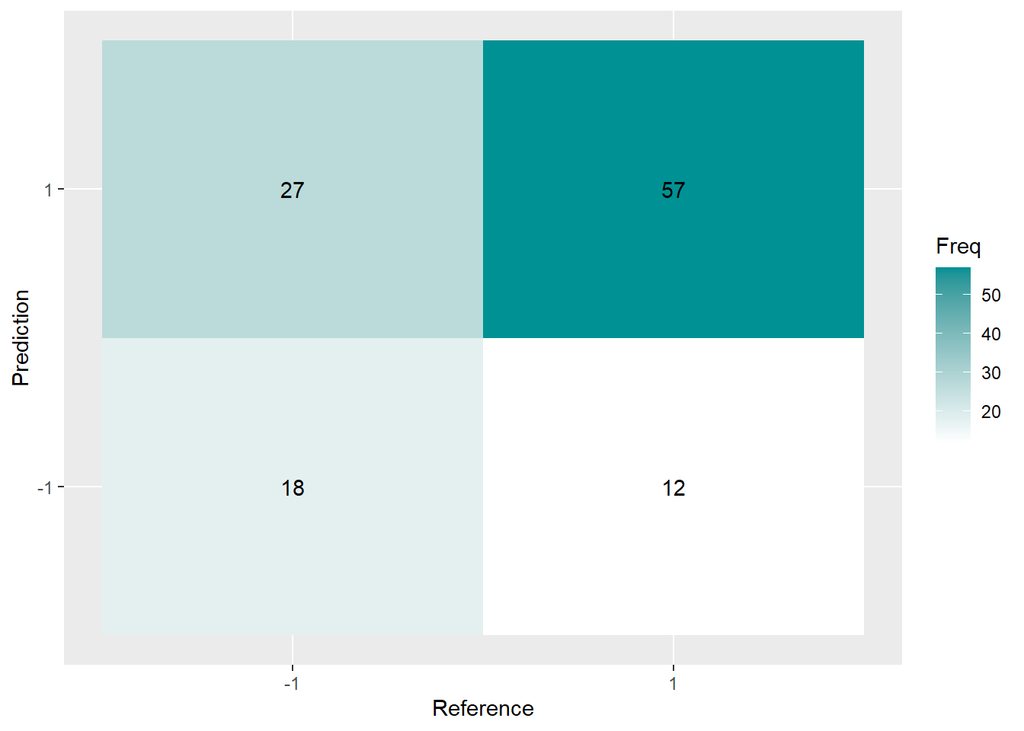

```r
prediction1 <- as.factor(ifelse(pred1 > result$best_threshold, '1', '-1'))
cm <- confusionMatrix(prediction1, session_1$feedback_type, dnn = c("Prediction", "Reference"))

plt <- as.data.frame(cm$table)

ggplot(plt, aes(Reference, Prediction, fill= Freq)) +
        geom_tile() + geom_text(aes(label=Freq)) +
        scale_fill_gradient(low="white", high="#009194") +
        labs(x = "Reference",y = "Prediction") +
        scale_x_discrete(labels=c("-1","1")) +
        scale_y_discrete(labels=c("-1","1"))
```

```r
thresholds <- seq(0.3, 0.8, by = 0.1)
result <- find_best_threshold(pred2, session_1$feedback_type, thresholds)
print("--Model 2--")
```

```
## [1] "--Model 2--"
```

```r
print(paste("Best Threshold:", result$best_threshold))
```

```
## [1] "Best Threshold: 0.6"
```

```r
print(paste("Minimum Error Rate:", result$min_error_rate))
```

```
## [1] "Minimum Error Rate: 0.298245614035088"
```

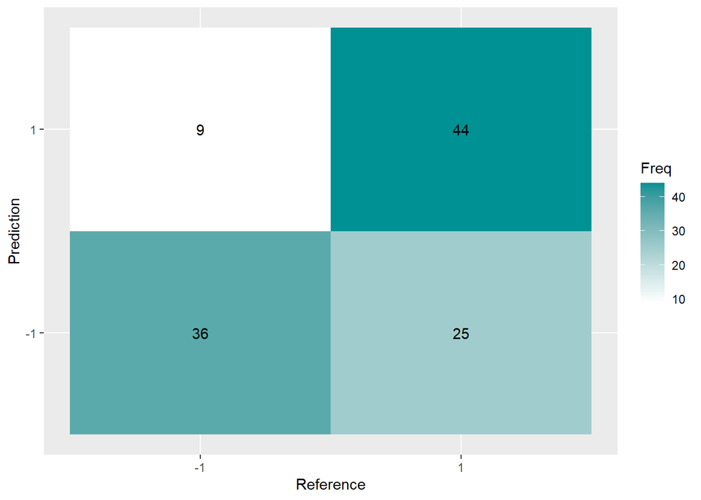

```r
prediction2 <- as.factor(ifelse(pred2 > result$best_threshold, '1', '-1'))
cm <- confusionMatrix(prediction2, session_1$feedback_type, dnn = c("Prediction", "Reference"))

plt <- as.data.frame(cm$table)

ggplot(plt, aes(Reference, Prediction, fill= Freq)) +
        geom_tile() + geom_text(aes(label=Freq)) +
        scale_fill_gradient(low="white", high="#009194") +
        labs(x = "Reference",y = "Prediction") +
        scale_x_discrete(labels=c("-1","1")) +
        scale_y_discrete(labels=c("-1","1"))
```

```r
thresholds <- seq(0.3, 0.8, by = 0.1)
result <- find_best_threshold(pred3, session_1$feedback_type, thresholds)
print("--Model 3--")
```

```
## [1] "--Model 3--"
```

```r
print(paste("Best Threshold:", result$best_threshold))
```

```
## [1] "Best Threshold: 0.6"
```

```r
print(paste("Minimum Error Rate:", result$min_error_rate))
```

```
## [1] "Minimum Error Rate: 0.307017543859649"
```

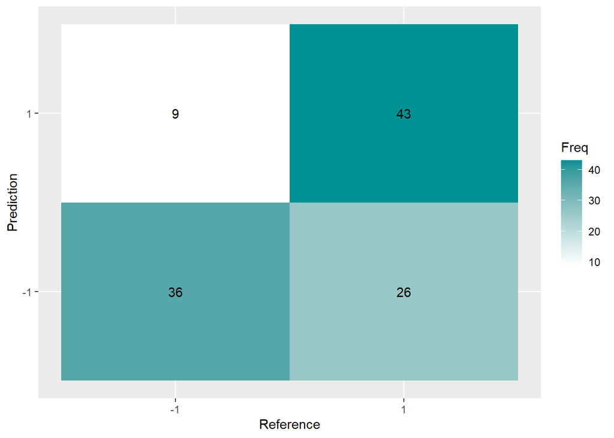

```r
prediction3 <- as.factor(ifelse(pred3 > result$best_threshold, '1', '-1'))
cm <- confusionMatrix(prediction3, session_1$feedback_type, dnn = c("Prediction", "Reference"))

plt <- as.data.frame(cm$table)

ggplot(plt, aes(Reference, Prediction, fill= Freq)) +
        geom_tile() + geom_text(aes(label=Freq)) +
        scale_fill_gradient(low="white", high="#009194") +
        labs(x = "Reference",y = "Prediction") +
        scale_x_discrete(labels=c("-1","1")) +
        scale_y_discrete(labels=c("-1","1"))
```

The optimal prediction errors for the three models were 34%, 30%, and 31%, respectively. In terms of accuracy, Model2 is the best model for predicting session 1.

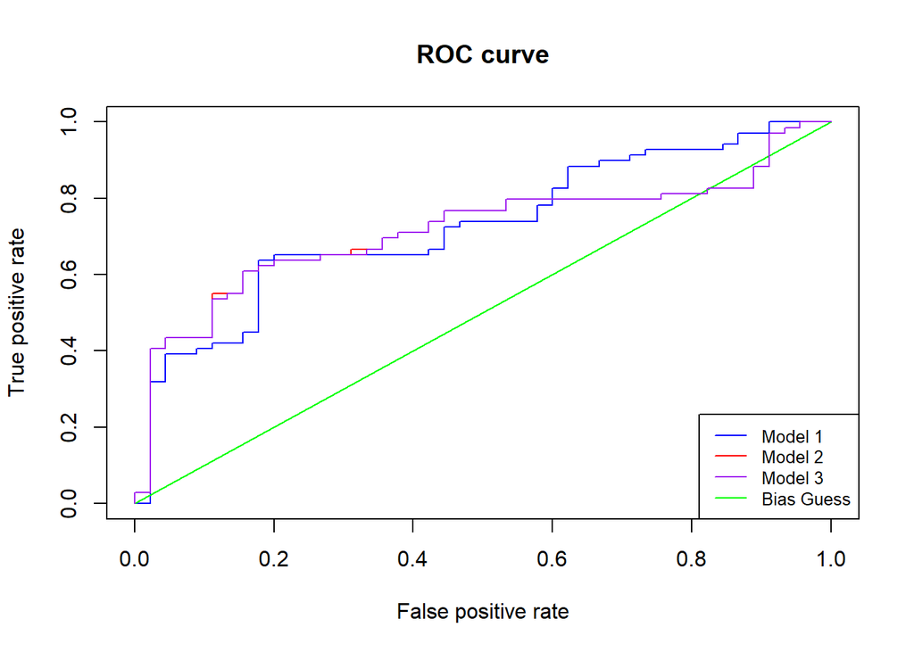

```r
# Model 1
pr = prediction(pred1, session_1$feedback_type)
prf <- performance(pr, measure = "tpr", x.measure = "fpr")
auc <- performance(pr, measure = "auc")
auc <- auc@y.values[[1]]

# Model 2
pr = prediction(pred2, session_1$feedback_type)
prf2 <- performance(pr, measure = "tpr", x.measure = "fpr")
auc2 <- performance(pr, measure = "auc")
auc2 <- auc2@y.values[[1]]

# Model 3
pr = prediction(pred3, session_1$feedback_type)
prf3 <- performance(pr, measure = "tpr", x.measure = "fpr")
auc3 <- performance(pr, measure = "auc")
auc3 <- auc3@y.values[[1]]

# Bias Guess
pred0 = pred1 * 0 + 1
pr = prediction(pred0, session_1$feedback_type)
prf0 <- performance(pr, measure = "tpr", x.measure = "fpr")
auc0 <- performance(pr, measure = "auc")
auc0 <- auc0@y.values[[1]]

plot(prf2, ,col = 'red', main = 'ROC curve')
plot(prf, add = TRUE, col = 'blue')
plot(prf0, add = TRUE, col = 'green')
plot(prf3, add = TRUE, col = 'purple')
legend("bottomright", legend=c("Model 1", "Model 2", "Model 3", "Bias Guess"), col=c("blue", "red","purple", 'green'), lty=1:1,
       cex=0.8)
```

From ROC curve, we see that Mode 1, Model 2 and Model 3 have similar performance in Session 1.

```r
# AUC
print(c(auc, auc2, auc3, auc0))
```

```
## [1] 0.7256039 0.7175523 0.7165862 0.5000000
```

From AUC, Model 1 is slgithly better than Model 2 and Model 3 for session 1.

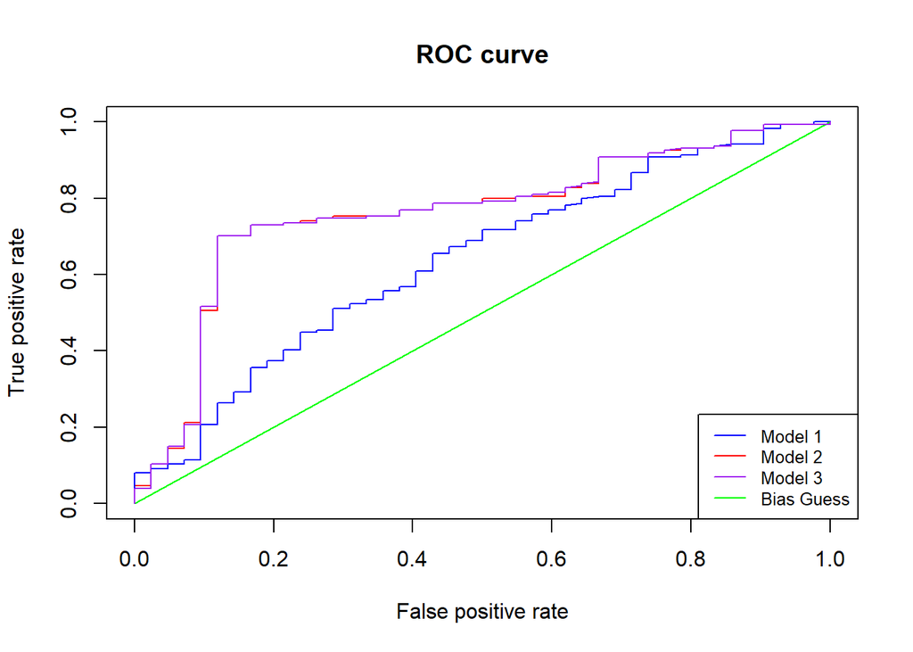

```r
session_18 <- subset(session_bench, session_ID==18)
pred1 <- predict(fit1, session_18 %>% dplyr::select(-feedback_type), type = 'response')
pred2 <- predict(fit2, session_18 %>% dplyr::select(-feedback_type), type = 'response')
pred3 <- predict(fit3, session_18 %>% dplyr::select(-feedback_type), type = 'response')


# Model 1
pr = prediction(pred1, session_18$feedback_type)
prf <- performance(pr, measure = "tpr", x.measure = "fpr")
auc <- performance(pr, measure = "auc")
auc <- auc@y.values[[1]]

# Model 2
pr = prediction(pred2, session_18$feedback_type)
prf2 <- performance(pr, measure = "tpr", x.measure = "fpr")
auc2 <- performance(pr, measure = "auc")
auc2 <- auc2@y.values[[1]]

# Model 3
pr = prediction(pred3, session_18$feedback_type)
prf3 <- performance(pr, measure = "tpr", x.measure = "fpr")
auc3 <- performance(pr, measure = "auc")
auc3 <- auc3@y.values[[1]]

# Bias Guess
pred0 = pred1 * 0 + 1
pr = prediction(pred0, session_18$feedback_type)
prf0 <- performance(pr, measure = "tpr", x.measure = "fpr")
auc0 <- performance(pr, measure = "auc")
auc0 <- auc0@y.values[[1]]

plot(prf2, ,col = 'red', main = 'ROC curve')
plot(prf, add = TRUE, col = 'blue')
plot(prf0, add = TRUE, col = 'green')
plot(prf3, add = TRUE, col = 'purple')
legend("bottomright", legend=c("Model 1", "Model 2", "Model 3", "Bias Guess"), col=c("blue", "red","purple", 'green'), lty=1:1,
       cex=0.8)
```

From ROC curve, Model 2 and Model 3 is clearly better than Model 1 in session 18.

```r
# AUC
print(c(auc, auc2, auc3, auc0))
```

```
## [1] 0.6370416 0.7613574 0.7616995 0.5000000
```

From AUC, Model 2 and Model 3 exhibit similar performance and are significantly better than Model 1.

# Discussion